# Raw NIR Data in R

JH

Saturday, September 19, 2015

As I understand it, the raw (.dat) files RD generates are a sequence of unsigned, little-endian, 16-bit integers written for each position, then each wavelength, then each frame.

Based on the above, the following function loads raw data from file:

```r
readRaw <- function(filename, output.format='array') {
  finfo = file.info(filename)
  toread= file(filename, "rb")
  alldata = readBin(toread, integer(), size=2, n = finfo$size, endian="little") # limited to 2^31-1 elements!!!
  close(toread)
  nframes = length(alldata)/(320*256)
  if (nframes != floor(nframes)) {
    stop('amount of data is not nframes*320*256')
  }
  print(paste("reading",nframes,"frames..."))
  if (output.format=='array') {
    OUT = array(alldata, dim=c(320,256,nframes),
                dimnames=list(paste('position',1:320),
                              paste('wavelength',1:256),
                              paste('frame',1:nframes)))
  } else if (output.format=='long') {
    OUT = data.frame(position=rep(1:320, 256*nframes),
                    wavelength=rep(1:256, nframes, each=320),
                    frame=factor(rep(1:nframes, each=320*256), ordered=TRUE),
                    reflectance=alldata)
    OUT$reflectance[OUT$reflectance>(2^12-2)] = NA # clear saturated observations
    OUT$reflectance = OUT$reflectance/(2^12-1)
  } else {
    stop('unknown output.format')
  }
  return(OUT)
}
```

Best thing to do would be to put the above code in a seperate file and use `source()` to load it.

The function can return the data as either an array (`output.format='array'`) or as a data frame in long form (`output.format='long'`).

Here’s are examples of how to use the array form:

```r
I=readRaw('test1.dat')
```

```
## [1] "reading 1 frames..."
```

```r
str(I)
```

```
##  int [1:320, 1:256, 1] 349 349 349 369 372 373 372 372 0 0 ...
##  - attr(*, "dimnames")=List of 3
##   ..$ : chr [1:320] "position 1" "position 2" "position 3" "position 4" ...
##   ..$ : chr [1:256] "wavelength 1" "wavelength 2" "wavelength 3" "wavelength 4" ...
##   ..$ : chr "frame 1"
```

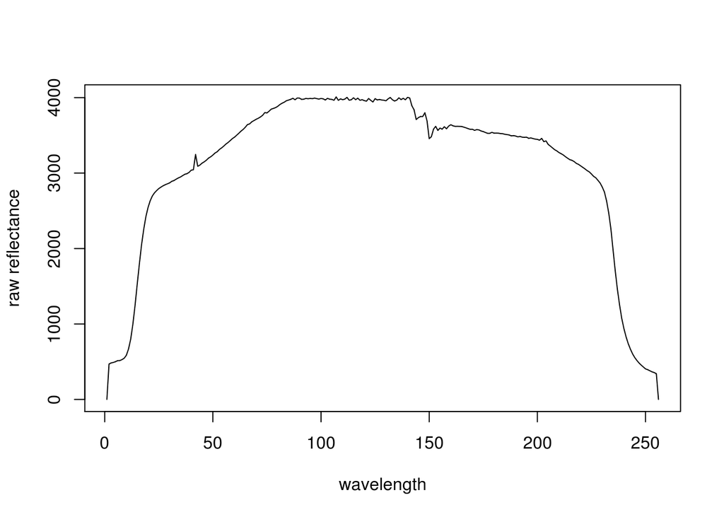

```r
position=1:320
wavelength=1:256
plot(wavelength, I["position 200",,"frame 1"], type='l', ylab="raw reflectance")
```

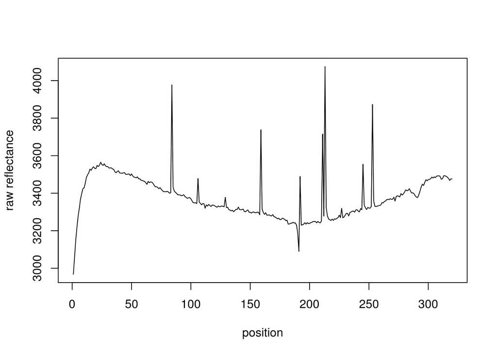

```r
plot(position, I[,"wavelength 50","frame 1"], type='l', ylab="raw reflectance")
```

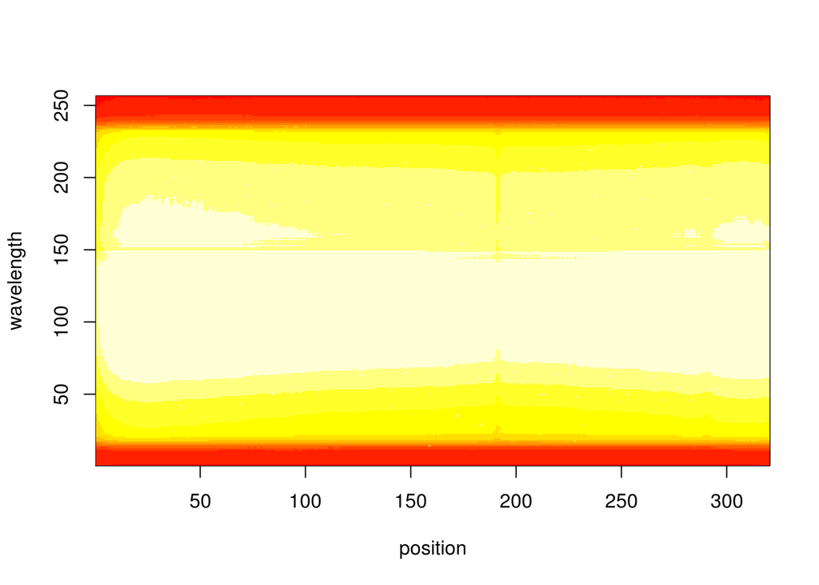

```r
image(position,wavelength,I[,,1])
```

The data frame form makes it easy to slice and dice:

```r
I=readRaw('test10.dat', output.format='long')
```

```
## [1] "reading 10 frames..."
```

```r
str(I)
```

```
## 'data.frame':    819200 obs. of  4 variables:
##  $ position   : int  1 2 3 4 5 6 7 8 9 10 ...
##  $ wavelength : int  1 1 1 1 1 1 1 1 1 1 ...
##  $ frame      : Ord.factor w/ 10 levels "1"<"2"<"3"<"4"<..: 1 1 1 1 1 1 1 1 1 1 ...
##  $ reflectance: num  0.0852 0.0852 0.0852 0.0901 0.0906 ...
```

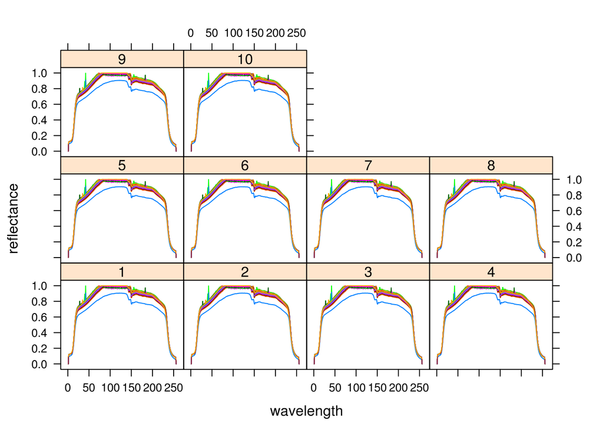

```r
library(lattice)
xyplot(reflectance ~ wavelength | frame, group=position, I, subset=position%in%c(seq(1,320,by=20),320), type='l')
```

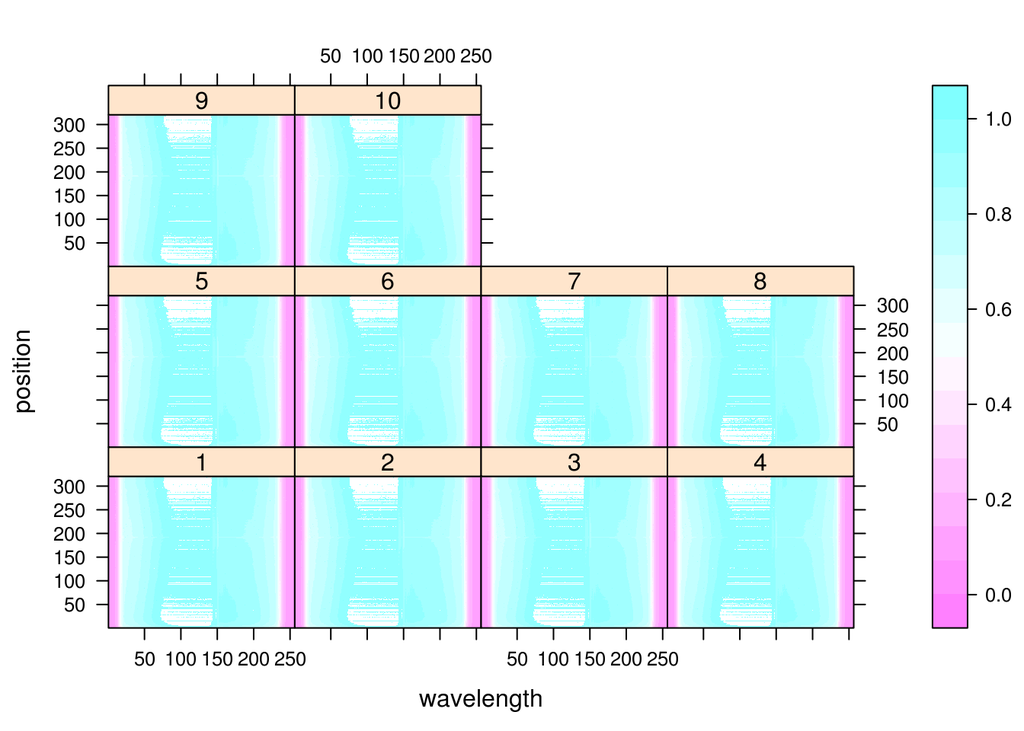

```r
levelplot(reflectance ~ wavelength*position | frame, I)
```

Note that the data frame form has missing values where the sensor saturated, so the % of saturated measurments is

```r
sum(is.na(I$reflectance))/nrow(I)*100
```

```
## [1] 7.587158
```

Also, the reflectance is scaled to the range [0..1).

# A Wood Example

```r
I=readRaw('230915_131536_X706.dat',output.format='long')
```

```
## [1] "reading 706 frames..."
```

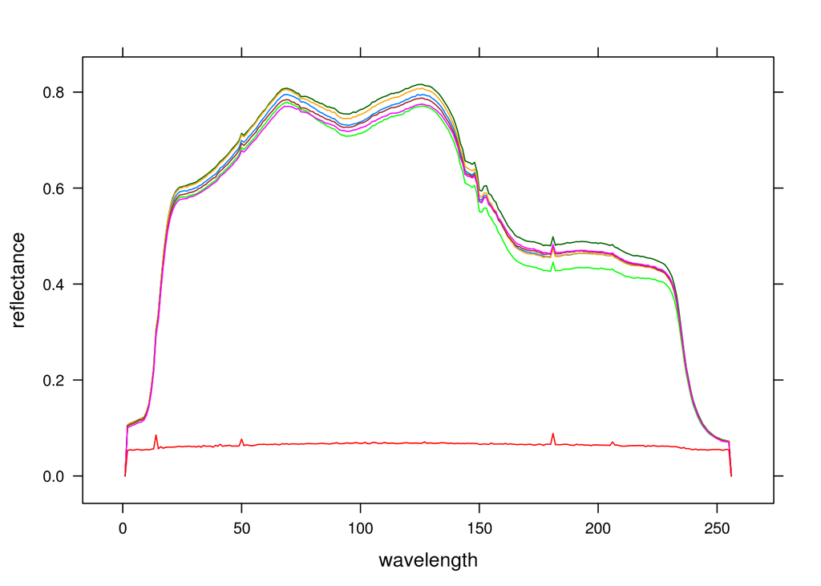

```r
xyplot(reflectance ~ wavelength, group=paste(frame,position),
       I,
       subset=position==160&frame%in%seq(100,706,by=100),
       type='l')
```

# End Effects

```r
fp <- function(fn) {
  paste("../NIRlight/darksides_experiment/",fn,sep="")
  }
add_scan <- function(fn,lbl,out=NULL) {
  tmp <- readRaw(fn,output.format='long')
  tmp$lbl <- lbl
  if (is.null(out)) return(tmp)
  return(rbind(R,tmp))
}
R=add_scan(fp('250915_113105_0-WR-no_cardboard.dat'),'as is')
```

```
## [1] "reading 1 frames..."
```

```r
R=add_scan(fp('250915_111533_0-WR+cardboard.dat'),'full',R)
```

```
## [1] "reading 1 frames..."
```

```r
R=add_scan(fp('250915_114207_0-WR-short_cardboard.dat'),'part',R)
```

```
## [1] "reading 1 frames..."
```

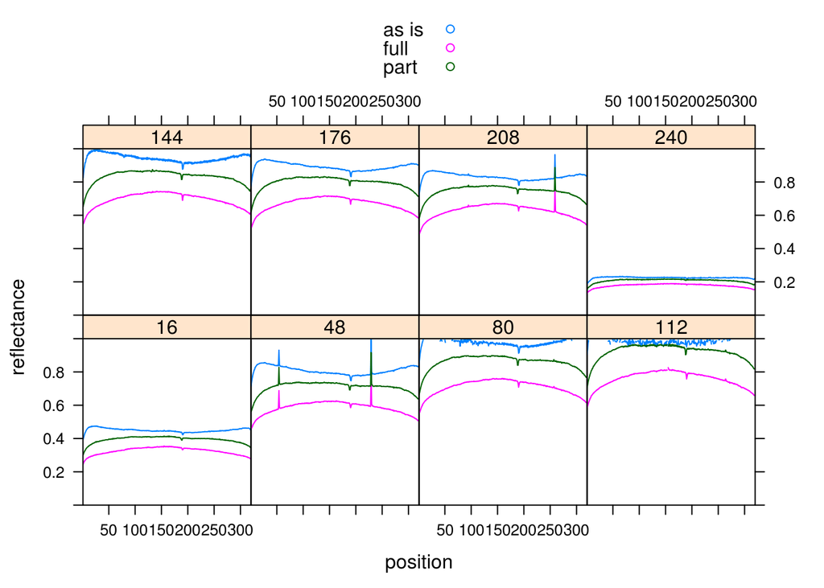

```r
xyplot(reflectance ~ position | as.factor(wavelength), group=lbl, R, subset=wavelength%in%seq(16,256,by=32), type='l', auto.key=TRUE, xlim=c(1,320), ylim=c(0,1))
```

Initially it seems surprising how much effect reducing reflection from ends are, until you think about where the lamps are placed, and how far from the ideal line source the design really is.

Why does the light intensity roll-off significantly right next to one end, but not the other? Is this just due to the camera not being centered? How wide is the field of view? How wide is the illuminator slot?

Perhaps rather than trying to flatten the illumination profile by reducing light at the ends, we’d be better off injecting more light in the middle? Currently 2 lamps, positioned 1/4 of the way from either end?

Does the black card absorb uniformly across the spectral range? The next figure plots the ratio of signal with the black card installed to that without at a position near the illuminator end, where the white reference reflection is most strongly affected by introducing the black card. Away form the dodgy low and high wavelengths, the ratio is between 60 and 70%, with the card absorbing less at longer wavelengths and with a strange reduction in absorbance near the middle of the wavelength range.

```r
asis = readRaw(fp('250915_113105_0-WR-no_cardboard.dat'))
```

```
## [1] "reading 1 frames..."
```

```r
card = readRaw(fp('250915_111533_0-WR+cardboard.dat'))
```

```
## [1] "reading 1 frames..."
```

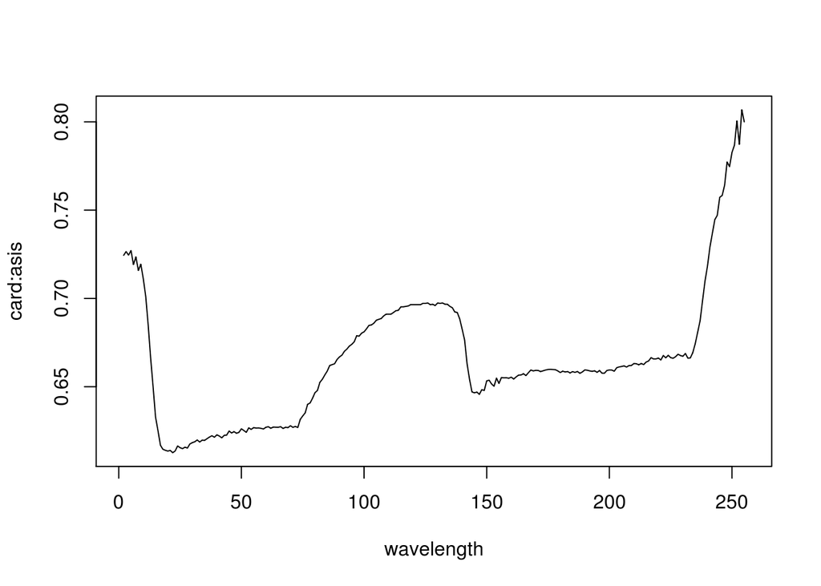

```r
ratio = card/asis
plot(ratio[20,,1], type='l', xlab="wavelength", ylab="card:asis", main="")
```